# Predicting Provincial Voter Turnout Percentages in the 2025 Philippine Elections Using Linear Regression

### Correlation Analysis

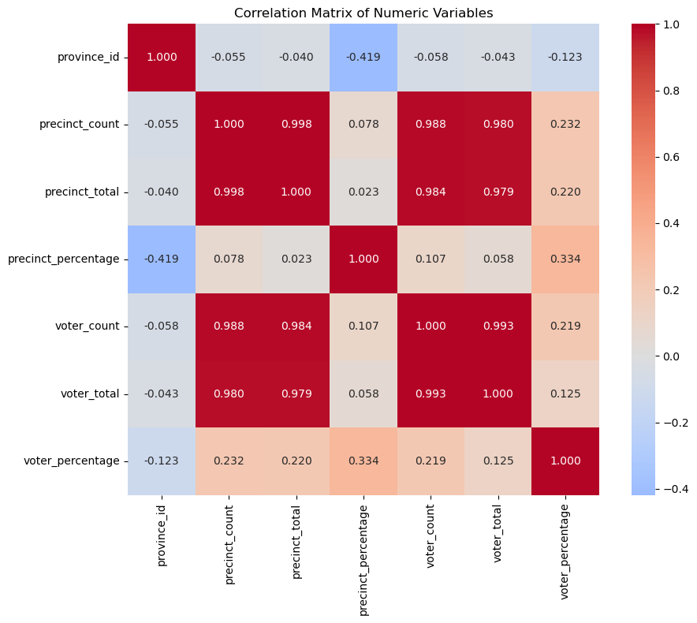

```
Correlations with Voter Percentage (strongest first):
  precinct_percentage: 0.334
  precinct_count: 0.232
  precinct_total: 0.220
  voter_count: 0.219
  voter_total: 0.125
  province_id: 0.123
```

```python
# Calculating the correlation matrix
numeric_columns = df.select_dtypes(include=[np.number]).columns
correlation_matrix = df[numeric_columns].corr()

# Correlation heatmap
plt.figure(figsize=(10, 8))
sns.heatmap(correlation_matrix, annot=True, cmap='coolwarm', center=0,
            square=True, fmt='.3f')
plt.title('Correlation Matrix of Numeric Variables')
plt.tight_layout()
plt.show()

# Finding correlations with target variable
target_correlations = correlation_matrix['voter_percentage'].abs().sort_values(ascending=False)
print("\nCorrelations with Voter Percentage (strongest first):")
for feature, corr in target_correlations.items():
    if feature != 'voter_percentage':
        print(f"  {feature}: {corr:.3f}")
```

- Precinct_percentage is the most useful variable for prediction because it has the best correlation (0.334) with voter turnout.
- There is a strong correlation (0.98+) between voter and precinct-related variables, suggesting possible multicollinearity problems.
- The majority of features exhibit weak to moderate correlations with voter turnout (0.125-0.334), indicating that numerous features are necessary for modeling.
- Precinct-related variables are important predictors, and the correlation analysis shows that the features we chose are the most pertinent.

### Feature Analysis

```python
# Identifying potential features for modeling
print("FEATURE IDENTIFICATION:")
numeric_features = list(df.select_dtypes(include=[np.number]).columns)
categorical_features = list(df.select_dtypes(include=['object']).columns)

print(f"Numeric features: {numeric_features}")
print(f"Categorical features: {categorical_features}")

# Provinces with extreme values
print("\nEXTREME VALUES ANALYSIS:")
print("\nTop 5 Provinces by Voter Turnout:")
top_5 = df.nlargest(5, 'voter_percentage')[['location_name', 'voter_percentage']]
for idx, row in top_5.iterrows():
    print(f"  {row['location_name']}: {row['voter_percentage']:.2f}%")

print("\nBottom 5 Provinces by Voter Turnout:")
bottom_5 = df.nsmallest(5, 'voter_percentage')[['location_name', 'voter_percentage']]
for idx, row in bottom_5.iterrows():
    print(f"  {row['location_name']}: {row['voter_percentage']:.2f}%")

# Summary for modeling
print("\nMODELING PREPARATION SUMMARY:")
print("✓ Target variable: voter_percentage")
print("✓ Problem type: Regression")
print("✓ Dataset size: 125 provinces")
print("✓ No missing values")
print("✓ Ready for preprocessing and feature engineering")
```

```
FEATURE IDENTIFICATION:
Numeric features: ['province_id', 'precinct_count', 'precinct_total', 'precinct_percentage', 'voter_count', 'voter_total', 'voter_percentage']
Categorical features: ['location_name', 'type', 'slug', 'timestamp']

EXTREME VALUES ANALYSIS:

Top 5 Provinces by Voter Turnout:
  ABRA: 91.13%
  SIQUIJOR: 90.57%
  CAMIGUIN: 89.84%
  DAVAO DE ORO: 89.47%
  ALBAY: 89.37%

Bottom 5 Provinces by Voter Turnout:
  NORTH AND LATIN AMERICAS: 7.19%
  EUROPE: 19.23%
  MIDDLE EAST AND AFRICAS: 19.49%
  ASIA PACIFIC: 24.16%
  LAV: 52.07%

MODELING PREPARATION SUMMARY:
✓ Target variable: voter_percentage
✓ Problem type: Regression
✓ Dataset size: 125 provinces
✓ No missing values
✓ Ready for preprocessing and feature engineering
```

## III. Data Preprocessing

### Feature Selection

```python
# Based on correlation analysis, selecting the features for modeling
print("SELECTING FEATURES BASED ON CORRELATION ANALYSIS:")

# Selecting the features with meaningful correlation (>0.1) and logical relevance
selected_features = [
    'precinct_percentage',  # strongest correlation (0.334)
    'precinct_count',       # good correlation (0.232)
    'precinct_total',       # good correlation (0.220)
    'voter_count',          # good correlation (0.219)
    'voter_total'           # moderate correlation (0.125)
]

print("Selected numeric features:")
for i, feature in enumerate(selected_features, 1):
    corr_value = df[['voter_percentage'] + selected_features].corr()['voter_percentage'][feature]
    print(f"  {i}. {feature}: {corr_value:.3f} correlation")

# Target variable
target = 'voter_percentage'
print(f"\nTarget variable: {target}")

# Creating feature and target datasets
X = df[selected_features].copy()
y = df[target].copy()

print(f"\nFeature matrix shape: {X.shape}")
print(f"Target vector shape: {y.shape}")

# Feature statistics
print(f"\nFEATURE STATISTICS:")
print(X.describe())
```

```
SELECTING FEATURES BASED ON CORRELATION ANALYSIS:
Selected numeric features:
  1. precinct_percentage: 0.334 correlation
  2. precinct_count: 0.232 correlation
  3. precinct_total: 0.220 correlation
  4. voter_count: 0.219 correlation
  5. voter_total: 0.125 correlation

Target variable: voter_percentage

Feature matrix shape: (125, 5)
Target vector shape: (125,)

FEATURE STATISTICS:
       precinct_percentage  precinct_count  precinct_total   voter_count  \
count           125.000000      125.000000      125.000000  1.250000e+02
mean             99.047360      742.464000      749.032000  4.557015e+05
std               3.584914      682.136439      683.666148  4.395848e+05
min              66.240000       33.000000       33.000000  1.148800e+04
25%              99.760000      268.000000      268.000000  1.535210e+05
50%             100.000000      555.000000      555.000000  3.458030e+05
75%             100.000000      882.000000      905.000000  5.370930e+05
max             100.000000     3027.000000     3028.000000  2.088301e+06

        voter_total
count  1.250000e+02
mean   5.581892e+05
std    5.204639e+05
min    1.365500e+04
25%    2.051670e+05
50%    4.070560e+05
75%    6.916020e+05
max    2.447362e+06
```

### Train-Test Split

```python
# Splitting the data into training and testing sets
X_train, X_test, y_train, y_test = train_test_split(
    X, y,
    test_size=0.2,      # 20% for testing
    random_state=42,    # for reproducibility
    shuffle=True
)

print("DATA SPLIT COMPLETED:")
print(f"  Training set: {X_train.shape[0]} samples ({X_train.shape[0]/len(X)*100:.1f}%)")
print(f"  Testing set:  {X_test.shape[0]} samples ({X_test.shape[0]/len(X)*100:.1f}%)")

print(f"\nTRAINING SET STATISTICS:")
print("Features (X_train):")
print(X_train.describe())

print(f"\nTarget variable (y_train) statistics:")
print(f"  Mean: {y_train.mean():.2f}%")
print(f"  Std:  {y_train.std():.2f}%")
print(f"  Min:  {y_train.min():.2f}%")
print(f"  Max:  {y_train.max():.2f}%")

print(f"\nTEST SET STATISTICS:")
print(f"Target variable (y_test) statistics:")
print(f"  Mean: {y_test.mean():.2f}%")
print(f"  Std:  {y_test.std():.2f}%")
print(f"  Min:  {y_test.min():.2f}%")
print(f"  Max:  {y_test.max():.2f}%")
```

```
DATA SPLIT COMPLETED:
  Training set: 100 samples (80.0%)
  Testing set:  25 samples (20.0%)

TRAINING SET STATISTICS:
Features (X_train):
       precinct_percentage  precinct_count  precinct_total   voter_count  \
count           100.000000      100.000000       100.00000  1.000000e+02
mean             99.000700      719.470000       726.50000  4.414642e+05
std               3.845983      656.627479       658.98947  4.250782e+05
min              66.240000       33.000000        33.00000  1.148800e+04
25%              99.745000      255.500000       255.75000  1.571772e+05
50%             100.000000      537.000000       541.50000  3.470780e+05
75%             100.000000      881.250000       888.50000  5.296718e+05
max             100.000000     3027.000000      3028.00000  2.088301e+06

        voter_total
count  1.000000e+02
mean   5.377659e+05
std    4.999290e+05
min    1.365500e+04
25%    1.978655e+05
50%    4.108755e+05
75%    6.833160e+05
max    2.447362e+06

Target variable (y_train) statistics:
  Mean: 80.83%
  Std:  12.85%
  Min:  7.19%
  Max:  91.13%

TEST SET STATISTICS:
Target variable (y_test) statistics:
  Mean: 77.38%
  Std:  13.41%
  Min:  24.16%
  Max:  87.66%
```

### Feature Scaling

```python
# Checking if the scaling is needed by looking at feature ranges
print("FEATURE RANGES (before scaling):")
for feature in X_train.columns:
    feature_range = X_train[feature].max() - X_train[feature].min()
    print(f"  {feature}: {X_train[feature].min():.0f} to {X_train[feature].max():.0f} (range: {feature_range:.0f})")

# Should scale the features
print("\nApplying StandardScaler...")

# Initializing and fitting the scaler on training data only
scaler = StandardScaler()
X_train_scaled = scaler.fit_transform(X_train)
X_test_scaled = scaler.transform(X_test)

# Converting back to DataFrames for easier handling
X_train_scaled = pd.DataFrame(X_train_scaled, columns=X_train.columns, index=X_train.index)
X_test_scaled = pd.DataFrame(X_test_scaled, columns=X_test.columns, index=X_test.index)

print("\nFEATURE RANGES (after scaling):")
for feature in X_train_scaled.columns:
    print(f"  {feature}: {X_train_scaled[feature].min():.3f} to {X_train_scaled[feature].max():.3f}")

print(f"\nScaled training set statistics:")
print(X_train_scaled.describe())
```

```
FEATURE RANGES (before scaling):
  precinct_percentage: 66 to 100 (range: 34)
  precinct_count: 33 to 3027 (range: 2994)
  precinct_total: 33 to 3028 (range: 2995)
  voter_count: 11488 to 2088301 (range: 2076813)
  voter_total: 13655 to 2447362 (range: 2433707)

Applying StandardScaler...

FEATURE RANGES (after scaling):
  precinct_percentage: -8.561 to 0.261
  precinct_count: -1.051 to 3.532
  precinct_total: -1.058 to 3.510
  voter_count: -1.017 to 3.894
  voter_total: -1.054 to 3.839

Scaled training set statistics:
       precinct_percentage  precinct_count  precinct_total   voter_count  \
count         1.000000e+02    1.000000e+02    1.000000e+02  1.000000e+02
mean          1.329492e-15   -5.329071e-17    2.664535e-17  2.442491e-17
std           1.005038e+00    1.005038e+00    1.005038e+00  1.005038e+00
min          -8.561074e+00   -1.050715e+00   -1.057671e+00 -1.016618e+00
25%           1.945016e-01   -7.101552e-01   -7.179501e-01 -6.721566e-01
50%           2.611385e-01   -2.792896e-01   -2.821471e-01 -2.231629e-01
75%           2.611385e-01    2.476214e-01    2.470694e-01  2.085545e-01
max           2.611385e-01    3.531919e+00    3.510063e+00  3.893715e+00

        voter_total
count  1.000000e+02
mean  -9.992007e-17
std    1.005038e+00
min   -1.053652e+00
25%   -6.833226e-01
50%   -2.550956e-01
75%    2.926082e-01
max    3.838978e+00
```

## IV. Model Training

### Linear Regression Model

```python
from sklearn.linear_model import LinearRegression
from sklearn.metrics import mean_absolute_error, mean_squared_error, r2_score

# Initializing and training Linear Regression model
lr_model = LinearRegression()
lr_model.fit(X_train_scaled, y_train)

# Making predictions
y_train_pred_lr = lr_model.predict(X_train_scaled)
y_test_pred_lr = lr_model.predict(X_test_scaled)

# Calculating performance metrics
print("LINEAR REGRESSION RESULTS:")
print("\nTraining Performance:")
train_mae_lr = mean_absolute_error(y_train, y_train_pred_lr)
train_rmse_lr = np.sqrt(mean_squared_error(y_train, y_train_pred_lr))
train_r2_lr = r2_score(y_train, y_train_pred_lr)

print(f"  MAE:  {train_mae_lr:.3f}")
print(f"  RMSE: {train_rmse_lr:.3f}")
print(f"  R²:   {train_r2_lr:.3f}")

print("\nTesting Performance:")
test_mae_lr = mean_absolute_error(y_test, y_test_pred_lr)
test_rmse_lr = np.sqrt(mean_squared_error(y_test, y_test_pred_lr))
test_r2_lr = r2_score(y_test, y_test_pred_lr)

print(f"  MAE:  {test_mae_lr:.3f}")
print(f"  RMSE: {test_rmse_lr:.3f}")
print(f"  R²:   {test_r2_lr:.3f}")

# Feature importance (coefficients)
print(f"\nFeature Coefficients:")
feature_importance_lr = pd.DataFrame({
    'Feature': X_train.columns,
    'Coefficient': lr_model.coef_
}).sort_values('Coefficient', key=abs, ascending=False)

for _, row in feature_importance_lr.iterrows():
    print(f"  {row['Feature']}: {row['Coefficient']:8.3f}")
```

```
LINEAR REGRESSION RESULTS:

Training Performance:
  MAE:  3.079
  RMSE: 6.040
  R²:   0.777

Testing Performance:
  MAE:  5.440
  RMSE: 8.610
  R²:   0.571

Feature Coefficients:
  precinct_total:  115.416
  precinct_count: -112.503
  voter_total:  -92.850
  voter_count:   91.801
  precinct_percentage:    6.857
```

### Random Forest Model

```python
from sklearn.ensemble import RandomForestRegressor

# Initializing and training Random Forest model
rf_model = RandomForestRegressor(
    n_estimators=100,
    random_state=42,
    max_depth=10
)
rf_model.fit(X_train_scaled, y_train)

# Making predictions
y_train_pred_rf = rf_model.predict(X_train_scaled)
y_test_pred_rf = rf_model.predict(X_test_scaled)

# Calculating performance metrics
print("RANDOM FOREST RESULTS:")
print("\nTraining Performance:")
train_mae_rf = mean_absolute_error(y_train, y_train_pred_rf)
train_rmse_rf = np.sqrt(mean_squared_error(y_train, y_train_pred_rf))
train_r2_rf = r2_score(y_train, y_train_pred_rf)

print(f"  MAE:  {train_mae_rf:.3f}")
print(f"  RMSE: {train_rmse_rf:.3f}")
print(f"  R²:   {train_r2_rf:.3f}")

print("\nTesting Performance:")
test_mae_rf = mean_absolute_error(y_test, y_test_pred_rf)
test_rmse_rf = np.sqrt(mean_squared_error(y_test, y_test_pred_rf))
test_r2_rf = r2_score(y_test, y_test_pred_rf)

print(f"  MAE:  {test_mae_rf:.3f}")
print(f"  RMSE: {test_rmse_rf:.3f}")
print(f"  R²:   {test_r2_rf:.3f}")

# Feature importance
print(f"\nFeature Importance:")
feature_importance_rf = pd.DataFrame({
    'Feature': X_train.columns,
    'Importance': rf_model.feature_importances_
}).sort_values('Importance', ascending=False)

for _, row in feature_importance_rf.iterrows():
    print(f"  {row['Feature']}: {row['Importance']:.3f}")
```

```
RANDOM FOREST RESULTS:

Training Performance:
  MAE:  2.263
  RMSE: 4.374
  R²:   0.883

Testing Performance:
  MAE:  6.562
  RMSE: 10.511
  R²:   0.360

Feature Importance:
  precinct_percentage: 0.361
  precinct_total: 0.207
  voter_count: 0.177
  precinct_count: 0.158
  voter_total: 0.099
```

### Decision Tree Model

```python
from sklearn.tree import DecisionTreeRegressor

# Initializing and training Decision Tree model
dt_model = DecisionTreeRegressor(
    max_depth=10,
    random_state=42,
    min_samples_split=5
)
dt_model.fit(X_train_scaled, y_train)

# Making predictions
y_train_pred_dt = dt_model.predict(X_train_scaled)
y_test_pred_dt = dt_model.predict(X_test_scaled)

# Calculating performance metrics
print("DECISION TREE RESULTS:")
print("\nTraining Performance:")
train_mae_dt = mean_absolute_error(y_train, y_train_pred_dt)
train_rmse_dt = np.sqrt(mean_squared_error(y_train, y_train_pred_dt))
train_r2_dt = r2_score(y_train, y_train_pred_dt)

print(f"  MAE:  {train_mae_dt:.3f}")
print(f"  RMSE: {train_rmse_dt:.3f}")
print(f"  R²:   {train_r2_dt:.3f}")

print("\nTesting Performance:")
test_mae_dt = mean_absolute_error(y_test, y_test_pred_dt)
test_rmse_dt = np.sqrt(mean_squared_error(y_test, y_test_pred_dt))
test_r2_dt = r2_score(y_test, y_test_pred_dt)

print(f"  MAE:  {test_mae_dt:.3f}")
print(f"  RMSE: {test_rmse_dt:.3f}")
print(f"  R²:   {test_r2_dt:.3f}")

# Feature importance
print(f"\nFeature Importance:")
feature_importance_dt = pd.DataFrame({
    'Feature': X_train.columns,
    'Importance': dt_model.feature_importances_
}).sort_values('Importance', ascending=False)

for _, row in feature_importance_dt.iterrows():
    print(f"  {row['Feature']}: {row['Importance']:.3f}")
```

```
DECISION TREE RESULTS:

Training Performance:
  MAE:  1.523
  RMSE: 2.221
  R²:   0.970

Testing Performance:
  MAE:  7.197
  RMSE: 13.553
  R²:   -0.063

Feature Importance:
  precinct_count: 0.853
  precinct_percentage: 0.090
  voter_total: 0.030
  voter_count: 0.018
  precinct_total: 0.010
```